# Case Study: Cyclistic bike-share analysis

# Capstone Project: Cyclistic

### Stakeholders

- Cyclistic executive team
- Lily Moreno: The director of marketing and my manager.

### Marketing Campaign Objectives

Design marketing strategies aimed at converting casual riders into annual members. In order to do that, however, the marketing analyst team needs to better understand how annual members and casual riders differ, why casual riders would buy a membership, and how digital media could affect their marketing tactics.

#### My task is to focus on (What is the question):

**How do annual members and casual riders use Cyclistic bikes differently?**

## Data

The data is the historical bike usage data provided by the client. It is their monthly usage spreadsheets (excel) for the past twelve month (organized by quarters). I have stored the data in its own sub-directory within the case study directory:

`(~\Documents\Coursera\Google Data Analytics\Capstone\Case Study Cyclistic\Data).`

The data will need to be formatted into proper data types such as numbers, dates, and text. There are missing data but more EDA is needed to determine if it will affect the overall analysis. Prior to any EDA there will be ETL needed in order to provide a tidy, coherent data source for analysis.

### Extract Transform and Load (ETL)

#### Step 1. Install the required packages and upload the data

```r
#install.packages('tidyverse')  #only need to install once
#install.packages('lubridate')
#install.packages('ggplot2')
library(tidyverse)  #helps wrangle data
library(lubridate)  #helps wrangle date attributes
library(ggplot2)  #helps visualize data
#getwd() #displays my working directory
#setwd("~Documents/Coursera/Google Data Analytics/Capstone/Case Study Cyclistic/Data") #sets my working directory to simplify calls to data
```

```r
# Upload Cyclistic datasets (csv files) here
q2_2019 <- read_csv("Divvy_Trips_2019_Q2.csv")
q3_2019 <- read_csv("Divvy_Trips_2019_Q3.csv")
q4_2019 <- read_csv("Divvy_Trips_2019_Q4.csv")
q1_2020 <- read_csv("Divvy_Trips_2020_Q1.csv")
```

#### STEP 2: WRANGLE DATA AND COMBINE INTO A SINGLE FILE

```r
# Compare column names each of the files
# While the names don't have to be in the same order, they DO need to
#match perfectly before we can use a command to join them into one file
colnames(q3_2019)
```

```
 [1] "trip_id"           "start_time"        "end_time"          "bikeid"            "tripduration"
 [6] "from_station_id"   "from_station_name" "to_station_id"     "to_station_name"   "usertype"
[11] "gender"            "birthyear"
```

```r
colnames(q4_2019)
```

```
 [1] "trip_id"           "start_time"        "end_time"          "bikeid"            "tripduration"
 [6] "from_station_id"   "from_station_name" "to_station_id"     "to_station_name"   "usertype"
[11] "gender"            "birthyear"
```

```r
colnames(q2_2019)
```

```
 [1] "01 - Rental Details Rental ID"                    "01 - Rental Details Local Start Time"
 [3] "01 - Rental Details Local End Time"               "01 - Rental Details Bike ID"
 [5] "01 - Rental Details Duration In Seconds Uncapped" "03 - Rental Start Station ID"
 [7] "03 - Rental Start Station Name"                   "02 - Rental End Station ID"
 [9] "02 - Rental End Station Name"                     "User Type"
[11] "Member Gender"                                    "05 - Member Details Member Birthday Year"
```

```r
colnames(q1_2020)
```

```
 [1] "ride_id"            "rideable_type"      "started_at"         "ended_at"           "start_station_name"
 [6] "start_station_id"   "end_station_name"   "end_station_id"     "start_lat"          "start_lng"
[11] "end_lat"            "end_lng"            "member_casual"
```

We will now rename the columns to make them consistent with q1_2020 (this is going-forward table design for Cyclistic)

```r
(q4_2019 <- rename(q4_2019
                   ,ride_id = trip_id
                   ,rideable_type = bikeid
                   ,started_at = start_time
                   ,ended_at = end_time
                   ,start_station_name = from_station_name
                   ,start_station_id = from_station_id
                   ,end_station_name = to_station_name
                   ,end_station_id = to_station_id
                   ,member_casual = usertype))
```

| ride_id | started_at | ended_at | rideable_type | tripduration | start_station_id | start_station_name | end_station_id | end_station_name | member_casual | gender | birthyear |
| --- | --- | --- | --- | --- | --- | --- | --- | --- | --- | --- | --- |
| 25223640 | 2019-10-01 00:01:39 | 2019-10-01 00:17:20 | 2215 | 940 | 20 | Sheffield Ave & Kingsbury St | 309 | Leavitt St & Armitage Ave | Subscriber | Male | 1987 |
| 25223641 | 2019-10-01 00:02:16 | 2019-10-01 00:06:34 | 6328 | 258 | 19 | Throop (Loomis) St & Taylor St | 241 | Morgan St & Polk St | Subscriber | Male | 1998 |
| 25223642 | 2019-10-01 00:04:32 | 2019-10-01 00:18:43 | 3003 | 850 | 84 | Milwaukee Ave & Grand Ave | 199 | Wabash Ave & Grand Ave | Subscriber | Female | 1991 |
| 25223643 | 2019-10-01 00:04:32 | 2019-10-01 00:43:43 | 3275 | 2350 | 313 | Lakeview Ave & Fullerton Pkwy | 290 | Kedzie Ave & Palmer Ct | Subscriber | Male | 1990 |
| 25223644 | 2019-10-01 00:04:34 | 2019-10-01 00:35:42 | 5294 | 1867 | 210 | Ashland Ave & Division St | 382 | Western Ave & Congress Pkwy | Subscriber | Male | 1987 |
| 25223645 | 2019-10-01 00:04:38 | 2019-10-01 00:10:51 | 1891 | 373 | 156 | Clark St & Wellington Ave | 226 | Racine Ave & Belmont Ave | Subscriber | Female | 1994 |
| 25223646 | 2019-10-01 00:04:52 | 2019-10-01 00:22:45 | 1061 | 1072 | 84 | Milwaukee Ave & Grand Ave | 142 | McClurg Ct & Erie St | Subscriber | Female | 1991 |
| 25223647 | 2019-10-01 00:04:57 | 2019-10-01 00:29:16 | 1274 | 1458 | 156 | Clark St & Wellington Ave | 463 | Clark St & Berwyn Ave | Subscriber | Male | 1995 |
| 25223648 | 2019-10-01 00:05:20 | 2019-10-01 00:29:18 | 6011 | 1437 | 156 | Clark St & Wellington Ave | 463 | Clark St & Berwyn Ave | Subscriber | Female | 1993 |
| 25223649 | 2019-10-01 00:05:20 | 2019-10-01 02:23:46 | 2957 | 8306 | 336 | Cottage Grove Ave & 47th St | 336 | Cottage Grove Ave & 47th St | Customer | NA | NA |

[output cut: 990 more lines]

```r
(q3_2019 <- rename(q3_2019
                   ,ride_id = trip_id
                   ,rideable_type = bikeid
                   ,started_at = start_time
                   ,ended_at = end_time
                   ,start_station_name = from_station_name
                   ,start_station_id = from_station_id
                   ,end_station_name = to_station_name
                   ,end_station_id = to_station_id
                   ,member_casual = usertype))
```

| ride_id | started_at | ended_at | rideable_type | tripduration | start_station_id | start_station_name | end_station_id | end_station_name | member_casual | gender | birthyear |
| --- | --- | --- | --- | --- | --- | --- | --- | --- | --- | --- | --- |
| 23479388 | 2019-07-01 00:00:27 | 2019-07-01 00:20:41 | 3591 | 1214 | 117 | Wilton Ave & Belmont Ave | 497 | Kimball Ave & Belmont Ave | Subscriber | Male | 1992 |
| 23479389 | 2019-07-01 00:01:16 | 2019-07-01 00:18:44 | 5353 | 1048 | 381 | Western Ave & Monroe St | 203 | Western Ave & 21st St | Customer | NA | NA |
| 23479390 | 2019-07-01 00:01:48 | 2019-07-01 00:27:42 | 6180 | 1554 | 313 | Lakeview Ave & Fullerton Pkwy | 144 | Larrabee St & Webster Ave | Customer | NA | NA |
| 23479391 | 2019-07-01 00:02:07 | 2019-07-01 00:27:10 | 5540 | 1503 | 313 | Lakeview Ave & Fullerton Pkwy | 144 | Larrabee St & Webster Ave | Customer | NA | NA |
| 23479392 | 2019-07-01 00:02:13 | 2019-07-01 00:22:26 | 6014 | 1213 | 168 | Michigan Ave & 14th St | 62 | McCormick Place | Customer | NA | NA |
| 23479393 | 2019-07-01 00:02:21 | 2019-07-01 00:07:31 | 4941 | 310 | 300 | Broadway & Barry Ave | 232 | Pine Grove Ave & Waveland Ave | Subscriber | Male | 1990 |
| 23479394 | 2019-07-01 00:02:24 | 2019-07-01 00:23:12 | 3770 | 1248 | 168 | Michigan Ave & 14th St | 62 | McCormick Place | Customer | NA | NA |
| 23479395 | 2019-07-01 00:02:26 | 2019-07-01 00:28:16 | 5442 | 1550 | 313 | Lakeview Ave & Fullerton Pkwy | 144 | Larrabee St & Webster Ave | Customer | NA | NA |
| 23479396 | 2019-07-01 00:02:34 | 2019-07-01 00:28:57 | 2957 | 1583 | 43 | Michigan Ave & Washington St | 195 | Columbus Dr & Randolph St | Customer | NA | NA |
| 23479397 | 2019-07-01 00:02:45 | 2019-07-01 00:29:14 | 6091 | 1589 | 43 | Michigan Ave & Washington St | 195 | Columbus Dr & Randolph St | Customer | NA | NA |

[output cut: 990 more lines]

```r
(q2_2019 <- rename(q2_2019
                   ,ride_id = "01 - Rental Details Rental ID"
                   ,rideable_type = "01 - Rental Details Bike ID"
                   ,started_at = "01 - Rental Details Local Start Time"
                   ,ended_at = "01 - Rental Details Local End Time"
                   ,start_station_name = "03 - Rental Start Station Name"
                   ,start_station_id = "03 - Rental Start Station ID"
                   ,end_station_name = "02 - Rental End Station Name"
                   ,end_station_id = "02 - Rental End Station ID"
                   ,member_casual = "User Type"))
```

| ride_id | started_at | ended_at | rideable_type | 01 - Rental Details Duration In Seconds Uncapped | start_station_id | start_station_name | end_station_id | end_station_name | member_casual | Member Gender | 05 - Member Details Member Birthday Year |
| --- | --- | --- | --- | --- | --- | --- | --- | --- | --- | --- | --- |
| 22178529 | 2019-04-01 00:02:22 | 2019-04-01 00:09:48 | 6251 | 446 | 81 | Daley Center Plaza | 56 | Desplaines St & Kinzie St | Subscriber | Male | 1975 |
| 22178530 | 2019-04-01 00:03:02 | 2019-04-01 00:20:30 | 6226 | 1048 | 317 | Wood St & Taylor St | 59 | Wabash Ave & Roosevelt Rd | Subscriber | Female | 1984 |
| 22178531 | 2019-04-01 00:11:07 | 2019-04-01 00:15:19 | 5649 | 252 | 283 | LaSalle St & Jackson Blvd | 174 | Canal St & Madison St | Subscriber | Male | 1990 |
| 22178532 | 2019-04-01 00:13:01 | 2019-04-01 00:18:58 | 4151 | 357 | 26 | McClurg Ct & Illinois St | 133 | Kingsbury St & Kinzie St | Subscriber | Male | 1993 |
| 22178533 | 2019-04-01 00:19:26 | 2019-04-01 00:36:13 | 3270 | 1007 | 202 | Halsted St & 18th St | 129 | Blue Island Ave & 18th St | Subscriber | Male | 1992 |
| 22178534 | 2019-04-01 00:19:39 | 2019-04-01 00:23:56 | 3123 | 257 | 420 | Ellis Ave & 55th St | 426 | Ellis Ave & 60th St | Subscriber | Male | 1999 |
| 22178535 | 2019-04-01 00:26:33 | 2019-04-01 00:35:41 | 6418 | 548 | 503 | Drake Ave & Fullerton Ave | 500 | Central Park Ave & Elbridge Ave | Subscriber | Male | 1969 |
| 22178536 | 2019-04-01 00:29:48 | 2019-04-01 00:36:11 | 4513 | 383 | 260 | Kedzie Ave & Milwaukee Ave | 499 | Kosciuszko Park | Subscriber | Male | 1991 |
| 22178537 | 2019-04-01 00:32:07 | 2019-04-01 01:07:44 | 3280 | 2137 | 211 | St. Clair St & Erie St | 211 | St. Clair St & Erie St | Customer | NA | NA |
| 22178538 | 2019-04-01 00:32:19 | 2019-04-01 01:07:39 | 5534 | 2120 | 211 | St. Clair St & Erie St | 211 | St. Clair St & Erie St | Customer | NA | NA |

[output cut: 990 more lines]

```r
NA
```

```r
# Inspect the dataframes and look for inconsistencies
str(q1_2020)
```

```
spec_tbl_df [426,887 x 13] (S3: spec_tbl_df/tbl_df/tbl/data.frame)
 $ ride_id           : chr [1:426887] "EACB19130B0CDA4A" "8FED874C809DC021" "789F3C21E472CA96" "C9A388DAC6ABF313" ...
 $ rideable_type     : chr [1:426887] "docked_bike" "docked_bike" "docked_bike" "docked_bike" ...
 $ started_at        : POSIXct[1:426887], format: "2020-01-21 20:06:59" "2020-01-30 14:22:39" "2020-01-09 19:29:26" "2020-01-06 16:17:07" ...
 $ ended_at          : POSIXct[1:426887], format: "2020-01-21 20:14:30" "2020-01-30 14:26:22" "2020-01-09 19:32:17" "2020-01-06 16:25:56" ...
 $ start_station_name: chr [1:426887] "Western Ave & Leland Ave" "Clark St & Montrose Ave" "Broadway & Belmont Ave" "Clark St & Randolph St" ...
 $ start_station_id  : num [1:426887] 239 234 296 51 66 212 96 96 212 38 ...
 $ end_station_name  : chr [1:426887] "Clark St & Leland Ave" "Southport Ave & Irving Park Rd" "Wilton Ave & Belmont Ave" "Fairbanks Ct & Grand Ave" ...
 $ end_station_id    : num [1:426887] 326 318 117 24 212 96 212 212 96 100 ...
 $ start_lat         : num [1:426887] 42 42 41.9 41.9 41.9 ...
 $ start_lng         : num [1:426887] -87.7 -87.7 -87.6 -87.6 -87.6 ...
 $ end_lat           : num [1:426887] 42 42 41.9 41.9 41.9 ...
 $ end_lng           : num [1:426887] -87.7 -87.7 -87.7 -87.6 -87.6 ...
 $ member_casual     : chr [1:426887] "member" "member" "member" "member" ...
 - attr(*, "spec")=
  .. cols(
  ..   ride_id = col_character(),
  ..   rideable_type = col_character(),
  ..   started_at = col_datetime(format = ""),
  ..   ended_at = col_datetime(format = ""),
  ..   start_station_name = col_character(),
  ..   start_station_id = col_double(),
  ..   end_station_name = col_character(),
  ..   end_station_id = col_double(),
  ..   start_lat = col_double(),
  ..   start_lng = col_double(),
  ..   end_lat = col_double(),
  ..   end_lng = col_double(),
  ..   member_casual = col_character()
  .. )
```

```r
str(q4_2019)
```

```
spec_tbl_df [704,054 x 12] (S3: spec_tbl_df/tbl_df/tbl/data.frame)
 $ ride_id           : num [1:704054] 25223640 25223641 25223642 25223643 25223644 ...
 $ started_at        : POSIXct[1:704054], format: "2019-10-01 00:01:39" "2019-10-01 00:02:16" "2019-10-01 00:04:32" "2019-10-01 00:04:32" ...
 $ ended_at          : POSIXct[1:704054], format: "2019-10-01 00:17:20" "2019-10-01 00:06:34" "2019-10-01 00:18:43" "2019-10-01 00:43:43" ...
 $ rideable_type     : num [1:704054] 2215 6328 3003 3275 5294 ...
 $ tripduration      : num [1:704054] 940 258 850 2350 1867 ...
 $ start_station_id  : num [1:704054] 20 19 84 313 210 156 84 156 156 336 ...
 $ start_station_name: chr [1:704054] "Sheffield Ave & Kingsbury St" "Throop (Loomis) St & Taylor St" "Milwaukee Ave & Grand Ave" "Lakeview Ave & Fullerton Pkwy" ...
 $ end_station_id    : num [1:704054] 309 241 199 290 382 226 142 463 463 336 ...
 $ end_station_name  : chr [1:704054] "Leavitt St & Armitage Ave" "Morgan St & Polk St" "Wabash Ave & Grand Ave" "Kedzie Ave & Palmer Ct" ...
 $ member_casual     : chr [1:704054] "Subscriber" "Subscriber" "Subscriber" "Subscriber" ...
 $ gender            : chr [1:704054] "Male" "Male" "Female" "Male" ...
 $ birthyear         : num [1:704054] 1987 1998 1991 1990 1987 ...
 - attr(*, "spec")=
  .. cols(
  ..   trip_id = col_double(),
  ..   start_time = col_datetime(format = ""),
  ..   end_time = col_datetime(format = ""),
  ..   bikeid = col_double(),
  ..   tripduration = col_number(),
  ..   from_station_id = col_double(),
  ..   from_station_name = col_character(),
  ..   to_station_id = col_double(),
  ..   to_station_name = col_character(),
  ..   usertype = col_character(),
  ..   gender = col_character(),
  ..   birthyear = col_double()
  .. )
```

```r
str(q3_2019)
```

```
spec_tbl_df [1,640,718 x 12] (S3: spec_tbl_df/tbl_df/tbl/data.frame)
 $ ride_id           : num [1:1640718] 23479388 23479389 23479390 23479391 23479392 ...
 $ started_at        : POSIXct[1:1640718], format: "2019-07-01 00:00:27" "2019-07-01 00:01:16" "2019-07-01 00:01:48" "2019-07-01 00:02:07" ...
 $ ended_at          : POSIXct[1:1640718], format: "2019-07-01 00:20:41" "2019-07-01 00:18:44" "2019-07-01 00:27:42" "2019-07-01 00:27:10" ...
 $ rideable_type     : num [1:1640718] 3591 5353 6180 5540 6014 ...
 $ tripduration      : num [1:1640718] 1214 1048 1554 1503 1213 ...
 $ start_station_id  : num [1:1640718] 117 381 313 313 168 300 168 313 43 43 ...
 $ start_station_name: chr [1:1640718] "Wilton Ave & Belmont Ave" "Western Ave & Monroe St" "Lakeview Ave & Fullerton Pkwy" "Lakeview Ave & Fullerton Pkwy" ...
 $ end_station_id    : num [1:1640718] 497 203 144 144 62 232 62 144 195 195 ...
 $ end_station_name  : chr [1:1640718] "Kimball Ave & Belmont Ave" "Western Ave & 21st St" "Larrabee St & Webster Ave" "Larrabee St & Webster Ave" ...
 $ member_casual     : chr [1:1640718] "Subscriber" "Customer" "Customer" "Customer" ...
 $ gender            : chr [1:1640718] "Male" NA NA NA ...
 $ birthyear         : num [1:1640718] 1992 NA NA NA NA ...
 - attr(*, "spec")=
  .. cols(
  ..   trip_id = col_double(),
  ..   start_time = col_datetime(format = ""),
  ..   end_time = col_datetime(format = ""),
  ..   bikeid = col_double(),
  ..   tripduration = col_number(),
  ..   from_station_id = col_double(),
  ..   from_station_name = col_character(),
  ..   to_station_id = col_double(),
  ..   to_station_name = col_character(),
  ..   usertype = col_character(),
  ..   gender = col_character(),
  ..   birthyear = col_double()
  .. )
```

```r
str(q2_2019)
```

```
spec_tbl_df [1,108,163 x 12] (S3: spec_tbl_df/tbl_df/tbl/data.frame)
 $ ride_id                                         : num [1:1108163] 22178529 22178530 22178531 22178532 22178533 ...
 $ started_at                                      : POSIXct[1:1108163], format: "2019-04-01 00:02:22" "2019-04-01 00:03:02" "2019-04-01 00:11:07" "2019-04-01 00:13:01" ...
 $ ended_at                                        : POSIXct[1:1108163], format: "2019-04-01 00:09:48" "2019-04-01 00:20:30" "2019-04-01 00:15:19" "2019-04-01 00:18:58" ...
 $ rideable_type                                   : num [1:1108163] 6251 6226 5649 4151 3270 ...
 $ 01 - Rental Details Duration In Seconds Uncapped: num [1:1108163] 446 1048 252 357 1007 ...
 $ start_station_id                                : num [1:1108163] 81 317 283 26 202 420 503 260 211 211 ...
 $ start_station_name                              : chr [1:1108163] "Daley Center Plaza" "Wood St & Taylor St" "LaSalle St & Jackson Blvd" "McClurg Ct & Illinois St" ...
 $ end_station_id                                  : num [1:1108163] 56 59 174 133 129 426 500 499 211 211 ...
 $ end_station_name                                : chr [1:1108163] "Desplaines St & Kinzie St" "Wabash Ave & Roosevelt Rd" "Canal St & Madison St" "Kingsbury St & Kinzie St" ...
 $ member_casual                                   : chr [1:1108163] "Subscriber" "Subscriber" "Subscriber" "Subscriber" ...
 $ Member Gender                                   : chr [1:1108163] "Male" "Female" "Male" "Male" ...
 $ 05 - Member Details Member Birthday Year        : num [1:1108163] 1975 1984 1990 1993 1992 ...
 - attr(*, "spec")=
  .. cols(
  ..   `01 - Rental Details Rental ID` = col_double(),
  ..   `01 - Rental Details Local Start Time` = col_datetime(format = ""),
  ..   `01 - Rental Details Local End Time` = col_datetime(format = ""),
  ..   `01 - Rental Details Bike ID` = col_double(),
  ..   `01 - Rental Details Duration In Seconds Uncapped` = col_number(),
  ..   `03 - Rental Start Station ID` = col_double(),
  ..   `03 - Rental Start Station Name` = col_character(),
  ..   `02 - Rental End Station ID` = col_double(),
  ..   `02 - Rental End Station Name` = col_character(),
  ..   `User Type` = col_character(),
  ..   `Member Gender` = col_character(),
  ..   `05 - Member Details Member Birthday Year` = col_double()
  .. )
```

```r
# Convert ride_id and rideable_type to character so that they can stack correctly
q4_2019 <-  mutate(q4_2019, ride_id = as.character(ride_id)
                   ,rideable_type = as.character(rideable_type))
q3_2019 <-  mutate(q3_2019, ride_id = as.character(ride_id)
                   ,rideable_type = as.character(rideable_type))
q2_2019 <-  mutate(q2_2019, ride_id = as.character(ride_id)
                   ,rideable_type = as.character(rideable_type))

# Stack individual quarter's data frames into one big data frame
all_trips <- bind_rows(q2_2019, q3_2019, q4_2019, q1_2020)

# Remove lat, long, birthyear, and gender fields as this data was dropped beginning in 2020
all_trips <- all_trips %>%
  select(-c(start_lat, start_lng, end_lat, end_lng, birthyear, gender, "01 - Rental Details Duration In Seconds Uncapped", "05 - Member Details Member Birthday Year", "Member Gender", "tripduration"))
```

#### STEP 3: CLEAN UP AND ADD DATA TO PREPARE FOR ANALYSIS

We need to inspect the new table and determine its accuracy

```r
colnames(all_trips)  #List of column names
```

```
[1] "ride_id"            "started_at"         "ended_at"           "rideable_type"      "start_station_id"
[6] "start_station_name" "end_station_id"     "end_station_name"   "member_casual"
```

```r
nrow(all_trips)  #How many rows are in data frame?
```

```
[1] 3879822
```

```r
dim(all_trips)  #Dimensions of the data frame?
```

```
[1] 3879822       9
```

```r
head(all_trips)  #See the first 6 rows of data frame.  Also tail(all_trips)
```

| ride_id | started_at | ended_at | rideable_type | start_station_id | start_station_name | end_station_id | end_station_name | member_casual |
| --- | --- | --- | --- | --- | --- | --- | --- | --- |
| 22178529 | 2019-04-01 00:02:22 | 2019-04-01 00:09:48 | 6251 | 81 | Daley Center Plaza | 56 | Desplaines St & Kinzie St | Subscriber |
| 22178530 | 2019-04-01 00:03:02 | 2019-04-01 00:20:30 | 6226 | 317 | Wood St & Taylor St | 59 | Wabash Ave & Roosevelt Rd | Subscriber |
| 22178531 | 2019-04-01 00:11:07 | 2019-04-01 00:15:19 | 5649 | 283 | LaSalle St & Jackson Blvd | 174 | Canal St & Madison St | Subscriber |
| 22178532 | 2019-04-01 00:13:01 | 2019-04-01 00:18:58 | 4151 | 26 | McClurg Ct & Illinois St | 133 | Kingsbury St & Kinzie St | Subscriber |
| 22178533 | 2019-04-01 00:19:26 | 2019-04-01 00:36:13 | 3270 | 202 | Halsted St & 18th St | 129 | Blue Island Ave & 18th St | Subscriber |
| 22178534 | 2019-04-01 00:19:39 | 2019-04-01 00:23:56 | 3123 | 420 | Ellis Ave & 55th St | 426 | Ellis Ave & 60th St | Subscriber |

```r
str(all_trips)  #See list of columns and data types (numeric, character, etc)
```

```
tibble [3,879,822 x 9] (S3: tbl_df/tbl/data.frame)
 $ ride_id           : chr [1:3879822] "22178529" "22178530" "22178531" "22178532" ...
 $ started_at        : POSIXct[1:3879822], format: "2019-04-01 00:02:22" "2019-04-01 00:03:02" "2019-04-01 00:11:07" "2019-04-01 00:13:01" ...
 $ ended_at          : POSIXct[1:3879822], format: "2019-04-01 00:09:48" "2019-04-01 00:20:30" "2019-04-01 00:15:19" "2019-04-01 00:18:58" ...
 $ rideable_type     : chr [1:3879822] "6251" "6226" "5649" "4151" ...
 $ start_station_id  : num [1:3879822] 81 317 283 26 202 420 503 260 211 211 ...
 $ start_station_name: chr [1:3879822] "Daley Center Plaza" "Wood St & Taylor St" "LaSalle St & Jackson Blvd" "McClurg Ct & Illinois St" ...
 $ end_station_id    : num [1:3879822] 56 59 174 133 129 426 500 499 211 211 ...
 $ end_station_name  : chr [1:3879822] "Desplaines St & Kinzie St" "Wabash Ave & Roosevelt Rd" "Canal St & Madison St" "Kingsbury St & Kinzie St" ...
 $ member_casual     : chr [1:3879822] "Subscriber" "Subscriber" "Subscriber" "Subscriber" ...
```

```r
summary(all_trips)  #Statistical summary of data. Mainly for numerics
```

```
   ride_id            started_at                     ended_at                   rideable_type
 Length:3879822     Min.   :2019-04-01 00:02:22   Min.   :2019-04-01 00:09:48   Length:3879822
 Class :character   1st Qu.:2019-06-23 07:49:09   1st Qu.:2019-06-23 08:20:27   Class :character
 Mode  :character   Median :2019-08-14 17:43:38   Median :2019-08-14 18:02:04   Mode  :character
                    Mean   :2019-08-26 00:49:59   Mean   :2019-08-26 01:14:37
                    3rd Qu.:2019-10-12 12:10:21   3rd Qu.:2019-10-12 12:36:16
                    Max.   :2020-03-31 23:51:34   Max.   :2020-05-19 20:10:34

 start_station_id start_station_name end_station_id  end_station_name   member_casual
 Min.   :  1.0    Length:3879822     Min.   :  1.0   Length:3879822     Length:3879822
 1st Qu.: 77.0    Class :character   1st Qu.: 77.0   Class :character   Class :character
 Median :174.0    Mode  :character   Median :174.0   Mode  :character   Mode  :character
 Mean   :202.9                       Mean   :203.8
 3rd Qu.:291.0                       3rd Qu.:291.0
 Max.   :675.0                       Max.   :675.0
                                     NA's   :1
```

We have discovered several issues and inconsistencies that need to be corrected:

```r
# In the "member_casual" column, replace "Subscriber" with "member" and "Customer" with "casual"
# Before 2020, Cyclistic used different labels for these two types of riders ... we will want to make our dataframe consistent with their current nomenclature
# N.B.: "Level" is a special property of a column that is retained even if a subset does not contain any values from a specific level
# Begin by seeing how many observations fall under each usertype
table(all_trips$member_casual)
```

```
    casual   Customer     member Subscriber
     48480     857474     378407    2595461
```

```r
# Reassign to the desired values (we will go with the current 2020 labels)
all_trips <-  all_trips %>%
  mutate(member_casual = recode(member_casual
                           ,"Subscriber" = "member"
                           ,"Customer" = "casual"))

# Check to make sure the proper number of observations were reassigned
table(all_trips$member_casual)
```

```
 casual  member
 905954 2973868
```

```r
# Add columns that list the date, month, day, and year of each ride
# This will allow us to aggregate ride data for each month, day, or year ... before completing these operations we could only aggregate at the ride level
# https://www.statmethods.net/input/dates.html more on date formats in R found at that link
all_trips$date <- as.Date(all_trips$started_at) #The default format is yyyy-mm-dd
all_trips$month <- format(as.Date(all_trips$date), "%m")
all_trips$day <- format(as.Date(all_trips$date), "%d")
all_trips$year <- format(as.Date(all_trips$date), "%Y")
all_trips$day_of_week <- format(as.Date(all_trips$date), "%A")

# Add a "ride_length" calculation to all_trips (in seconds)
# https://stat.ethz.ch/R-manual/R-devel/library/base/html/difftime.html
all_trips$ride_length <- difftime(all_trips$ended_at,all_trips$started_at)

# Inspect the structure of the columns
str(all_trips)
```

```
tibble [3,879,822 x 15] (S3: tbl_df/tbl/data.frame)
 $ ride_id           : chr [1:3879822] "22178529" "22178530" "22178531" "22178532" ...
 $ started_at        : POSIXct[1:3879822], format: "2019-04-01 00:02:22" "2019-04-01 00:03:02" "2019-04-01 00:11:07" "2019-04-01 00:13:01" ...
 $ ended_at          : POSIXct[1:3879822], format: "2019-04-01 00:09:48" "2019-04-01 00:20:30" "2019-04-01 00:15:19" "2019-04-01 00:18:58" ...
 $ rideable_type     : chr [1:3879822] "6251" "6226" "5649" "4151" ...
 $ start_station_id  : num [1:3879822] 81 317 283 26 202 420 503 260 211 211 ...
 $ start_station_name: chr [1:3879822] "Daley Center Plaza" "Wood St & Taylor St" "LaSalle St & Jackson Blvd" "McClurg Ct & Illinois St" ...
 $ end_station_id    : num [1:3879822] 56 59 174 133 129 426 500 499 211 211 ...
 $ end_station_name  : chr [1:3879822] "Desplaines St & Kinzie St" "Wabash Ave & Roosevelt Rd" "Canal St & Madison St" "Kingsbury St & Kinzie St" ...
 $ member_casual     : chr [1:3879822] "member" "member" "member" "member" ...
 $ date              : Date[1:3879822], format: "2019-04-01" "2019-04-01" "2019-04-01" "2019-04-01" ...
 $ month             : chr [1:3879822] "04" "04" "04" "04" ...
 $ day               : chr [1:3879822] "01" "01" "01" "01" ...
 $ year              : chr [1:3879822] "2019" "2019" "2019" "2019" ...
 $ day_of_week       : chr [1:3879822] "Monday" "Monday" "Monday" "Monday" ...
 $ ride_length       : 'difftime' num [1:3879822] 446 1048 252 357 ...
  ..- attr(*, "units")= chr "secs"
```

```r
# Convert "ride_length" from Factor to numeric so we can run calculations on the data
is.factor(all_trips$ride_length)
```

```
[1] FALSE
```

```r
all_trips$ride_length <- as.numeric(as.character(all_trips$ride_length))
is.numeric(all_trips$ride_length)
```

```
[1] TRUE
```

```r
# Remove "bad" data
# The dataframe includes a few hundred entries when bikes were taken out of docks and checked for quality by Cyclistic or ride_length was negative
# We will create a new version of the dataframe (v2) since data is being removed
# https://www.datasciencemadesimple.com/delete-or-drop-rows-in-r-with-conditions-2/
all_trips_v2 <- all_trips[!(all_trips$start_station_name == "HQ QR" | all_trips$ride_length<0),]
```

### Exploratory Data Analysis

#### STEP 4: CONDUCT DESCRIPTIVE ANALYSIS

```r
# Descriptive analysis on ride_length (all figures in seconds)
mean(all_trips_v2$ride_length) #straight average (total ride length / rides)
```

```
[1] 1479.139
```

```r
median(all_trips_v2$ride_length) #midpoint number in the ascending array of ride lengths
```

```
[1] 712
```

```r
max(all_trips_v2$ride_length) #longest ride
```

```
[1] 9387024
```

```r
min(all_trips_v2$ride_length) #shortest ride
```

```
[1] 1
```

```r
# You can condense the four lines above to one line using summary() on the specific attribute
summary(all_trips_v2$ride_length)
```

```
   Min. 1st Qu.  Median    Mean 3rd Qu.    Max.
      1     412     712    1479    1289 9387024
```

We will now begin our comparative analysis between members and casual riders.

```r
aggregate(all_trips_v2$ride_length ~ all_trips_v2$member_casual, FUN = mean)
```

| all_trips_v2$member_casual | all_trips_v2$ride_length |
| --- | --- |
| casual | 3552.7502 |
| member | 850.0662 |

```r
aggregate(all_trips_v2$ride_length ~ all_trips_v2$member_casual, FUN = median)
```

| all_trips_v2$member_casual | all_trips_v2$ride_length |
| --- | --- |
| casual | 1546 |
| member | 589 |

```r
aggregate(all_trips_v2$ride_length ~ all_trips_v2$member_casual, FUN = max)
```

| all_trips_v2$member_casual | all_trips_v2$ride_length |
| --- | --- |
| casual | 9387024 |
| member | 9056634 |

```r
aggregate(all_trips_v2$ride_length ~ all_trips_v2$member_casual, FUN = min)
```

| all_trips_v2$member_casual | all_trips_v2$ride_length |
| --- | --- |
| casual | 2 |
| member | 1 |

```r
# See the average ride time by each day for members vs casual users
aggregate(all_trips_v2$ride_length ~ all_trips_v2$member_casual + all_trips_v2$day_of_week, FUN = mean)
```

| all_trips_v2$member_casual | all_trips_v2$day_of_week | all_trips_v2$ride_length |
| --- | --- | --- |
| casual | Friday | 3773.8351 |
| member | Friday | 824.5305 |
| casual | Monday | 3372.2869 |
| member | Monday | 842.5726 |
| casual | Saturday | 3331.9138 |
| member | Saturday | 968.9337 |
| casual | Sunday | 3581.4054 |
| member | Sunday | 919.9746 |
| casual | Thursday | 3682.9847 |
| member | Thursday | 823.9278 |

[output cut: 4 more lines]

```r
# Notice that the days of the week are out of order. Let's fix that.
all_trips_v2$day_of_week <- ordered(all_trips_v2$day_of_week, levels=c("Sunday", "Monday", "Tuesday", "Wednesday", "Thursday", "Friday", "Saturday"))

# Now, let's run the average ride time by each day for members vs casual users
aggregate(all_trips_v2$ride_length ~ all_trips_v2$member_casual + all_trips_v2$day_of_week, FUN = mean)
```

| all_trips_v2$member_casual | all_trips_v2$day_of_week | all_trips_v2$ride_length |
| --- | --- | --- |
| casual | Sunday | 3581.4054 |
| member | Sunday | 919.9746 |
| casual | Monday | 3372.2869 |
| member | Monday | 842.5726 |
| casual | Tuesday | 3596.3599 |
| member | Tuesday | 826.1427 |
| casual | Wednesday | 3718.6619 |
| member | Wednesday | 823.9996 |
| casual | Thursday | 3682.9847 |
| member | Thursday | 823.9278 |

[output cut: 4 more lines]

We can provide an overall analysis of ridership trends by type and weekday

```r
all_trips_v2 %>%
  mutate(weekday = wday(started_at, label = TRUE)) %>%  #creates weekday field using wday()
  group_by(member_casual, weekday) %>%  #groups by usertype and weekday
  summarise(number_of_rides = n()                           #calculates the number of rides and average duration
  ,average_duration = mean(ride_length)) %>%        # calculates the average duration
  arrange(member_casual, weekday)                               # sorts
```

| member_casual | weekday | number_of_rides | average_duration |
| --- | --- | --- | --- |
| casual | Sun | 181293 | 3581.4054 |
| casual | Mon | 103296 | 3372.2869 |
| casual | Tue | 90510 | 3596.3599 |
| casual | Wed | 92457 | 3718.6619 |
| casual | Thu | 102679 | 3682.9847 |
| casual | Fri | 122404 | 3773.8351 |
| casual | Sat | 209543 | 3331.9138 |
| member | Sun | 267965 | 919.9746 |
| member | Mon | 472196 | 842.5726 |
| member | Tue | 508445 | 826.1427 |

[output cut: 4 more lines]

#### Step 5: Create Data Visulations to inspect the data more thoroughly

[figure not shown]

```r
# Let's visualize the number of rides by rider type
all_trips_v2 %>%
  mutate(weekday = wday(started_at, label = TRUE)) %>%
  group_by(member_casual, weekday) %>%
  summarise(number_of_rides = n()/100
            ,average_duration = mean(ride_length/60)) %>%
  arrange(member_casual, weekday)  %>%
  ggplot(aes(x = weekday, y = number_of_rides, fill = member_casual)) +
  geom_col(position = "dodge") +
labs(title = 'Number of Rides by Casual and Member Riders', x = "Day of the Week", y = 'Number of Rides (scaled hundred thousands')
```

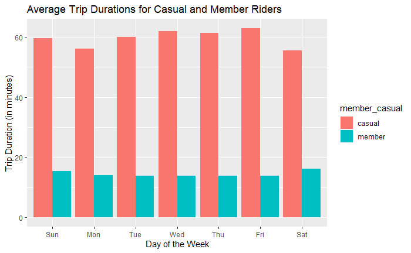

```r
# Let's create a visualization for average duration
all_trips_v2 %>%
  mutate(weekday = wday(started_at, label = TRUE)) %>%
  group_by(member_casual, weekday) %>%
  summarise(number_of_rides = n()
            ,average_duration = mean(ride_length/60)) %>%
  arrange(member_casual, weekday)  %>%
  ggplot(aes(x = weekday, y = average_duration, fill = member_casual)) +
  geom_col(position = "dodge") +
  labs(title = 'Average Trip Durations for Casual and Member Riders', x = "Day of the Week", y = 'Trip Duration (in minutes)')
```

#### STEP 6: EXPORT SUMMARY FILE FOR FURTHER ANALYSIS

WE will create a csv file that we will visualize in Excel, Tableau, or Kevin Hatman’s presentation software for alternatives to R. However we will continue in R for the analysis.

```r
counts <- aggregate(all_trips_v2$ride_length ~ all_trips_v2$member_casual + all_trips_v2$day_of_week, FUN = mean)
write.csv(counts, file = "C:/Users/Jack's PC/Documents/Coursera/Google Data Analytics/Capstone/Case Study Cyclistic/avg_ride_length.csv")
```

```r
View(counts)
glimpse(counts)
```

```
Rows: 14
Columns: 3
$ `all_trips_v2$member_casual` <chr> "casual", "member", "casual", "member", "casual", "member", "casual", "me~
$ `all_trips_v2$day_of_week`   <ord> Sunday, Sunday, Monday, Monday, Tuesday, Tuesday, Wednesday, Wednesday, T~
$ `all_trips_v2$ride_length`   <dbl> 3581.4054, 919.9746, 3372.2869, 842.5726, 3596.3599, 826.1427, 3718.6619,~
```

```r
all_trips_v2 %>%
  filter(member_casual == 'member') %>%
  group_by(member_casual) %>%
  summarise(member_casual = n())
```

| member_casual |
| --- |
| 2973860 |

```r
all_trips_v2 %>%
  filter(member_casual == 'casual') %>%
  group_by(member_casual) %>%
  summarise(member_casual = n())
```

| member_casual |
| --- |
| 902182 |

The aggregated spreadsheet confirms what we discovered in the first visualizations, the members ride much more often than do casual riders, but casual riders have much higher ride lengths.

### Conclusion

One can infer from the data that members and casual riders use the bike services for different reasons. The member cohort uses the service much more frequently but with small average trip times. This indicates that this cohort uses the service for more utilitarian purposes such as work commutes and running errands.

Cyclisitc should focus the campaign on showing the casual cohort the benefits of being members and that it ultimately would save them money. A cost benefit analysis to persuade them that they would get the “best of both worlds” with an annual membership rather than piece meal sign ups.

We will need more data to provde greater confidence and rigor such as financial data, customer surveys, and other preferences but this initial analysis does show how each cohort uses the service and how the company can move ahead to try to convince the casual group.